# Join Data Submission

Author

Heber, Lecksiwilai, Moreno

# Part 1: Find the Data

### First Dataset

Data Source: Our first dataset is from the Health Inequality Project: https://www.healthinequality.org/data/

Data Meaning: The data represents median household income compared to life expectancy, organized by state and year, adjusted by gender and race.

Data Join: We intend to join our data through the state and year variables, to be adjusted according to our second dataset if needed.

Data Observations: View glimpse() below.

Data Issues: There are no missing or bad values in the dataset.

```r
library(dplyr)

Health_Inequality_Project <- read.csv("C:/Users/lara/Downloads/health_ineq_online_table_5.csv")

glimpse(Health_Inequality_Project)
```

```
Rows: 714
Columns: 44
$ st                 <int> 1, 1, 1, 1, 1, 1, 1, 1, 1, 1, 1, 1, 1, 1, 2, 2, 2, …
$ stateabbrv         <chr> "AL", "AL", "AL", "AL", "AL", "AL", "AL", "AL", "AL…
$ statename          <chr> "Alabama", "Alabama", "Alabama", "Alabama", "Alabam…
$ year               <int> 2001, 2002, 2003, 2004, 2005, 2006, 2007, 2008, 200…
$ le_agg_q1_F        <dbl> 80.97743, 81.55089, 80.66910, 82.78710, 81.99500, 8…
$ le_raceadj_q1_F    <dbl> 81.73687, 82.29413, 81.44639, 83.54853, 82.79951, 8…
$ le_agg_q2_F        <dbl> 83.79784, 85.19556, 84.45503, 83.22166, 84.92139, 8…
$ le_raceadj_q2_F    <dbl> 84.27046, 85.62631, 84.91285, 83.73943, 85.40220, 8…
$ le_agg_q3_F        <dbl> 85.22591, 86.95561, 84.41888, 85.77566, 86.13605, 8…
$ le_raceadj_q3_F    <dbl> 85.57561, 87.24429, 84.79807, 86.11910, 86.47382, 8…
$ le_agg_q4_F        <dbl> 86.63757, 85.93870, 87.63429, 87.28502, 87.65756, 8…
$ le_raceadj_q4_F    <dbl> 86.91793, 86.24170, 87.87489, 87.53855, 87.89859, 8…
$ le_agg_q1_M        <dbl> 73.85774, 73.57462, 75.40674, 73.67553, 74.46228, 7…
```

[output cut: 31 more lines]

### Second Dataset

Data Source: Our second dataset is from the University of Minnesota, and is called State Health Compare: https://statehealthcompare.shadac.org/

Similarly, this data is also a collection of datasets from other sources, compiled into larger datasets set over greater spans of time. Various large national surveys, as well as government accessed data were used. This allows us to pull any variables we are interested in examining, and download data from the appropriate time frames to match our first dataset. We will specifically be looking at the percentage of adults who were unable to get medical care when needed due to cost. This data is from the Centers for Disease Control and Prevention’s (CDC) Behavioral Risk Factor Surveillance System (BRFSS) survey.

Data Join: We will be joining by state and year. Since we have to download two separate datasets to ensure we have the full 2005-2014 time frame within the first dataset, we will have to join two datasets from different time frames first, then join this combined dataset to the first. To note, we will have to convert the year column to be read as an integer to match the data type of the first dataset.

Data Observations: View glimpse() below.

Data Issues: Our second dataset, once the years are combined, has headings within the actual data tables, as well as empty rows. While these shouldn’t matter too much, they will have to be removed. This should not impact the reliability of the source, given that it was likely an error in converting files and joining them.

```r
SHADAC_1_df <- read.csv("C:/Users/lara/Downloads/Shadac-BulkData-02132026/Percent of adults who could not get medical care when needed due to cost by Total (2005 to 2010).csv")

SHADAC_2_df <- read.csv("C:/Users/lara/Downloads/Percent of adults who could not get medical care when needed due to cost by Total (2011 to 2024).csv")

both_SHADAC_df <- rbind(SHADAC_1_df, SHADAC_2_df)

## Right now, the year column is being read as an integer, which will cause problems once we join them. Let's change that first.
both_SHADAC_df$X.2 <- as.integer(both_SHADAC_df$X.2)
glimpse(both_SHADAC_df)
```

```
Rows: 998
Columns: 6
$ X   <chr> "", "", "", "", "Fips", "US", "US", "US", "US", "US", "1", "1", "1…
$ X.1 <chr> "", "", "", "", "Location", "United States", "United States", "Uni…
$ X.2 <int> NA, NA, NA, NA, NA, 2006, 2007, 2008, 2009, 2010, 2006, 2007, 2008…
$ X.3 <chr> "", "", "", "", "Data Type", "Percent", "Percent", "Percent", "Per…
$ X.4 <chr> "", "", "", "", "Data", "0.13304", "0.13523", "0.14072", "0.14906"…
$ X.5 <chr> "", "", "", "", "MOE", "0.002895592", "0.002475182", "0.002564892"…
```

# Part 2: Joining datasets

To join the datasets, we will need to join by year, and state. We performed a inner join on statename and year to understand how well the datasets align. A inner join should help filter out unwanted empty rows, as well as only keep data from years we want to examine. Any non-overlapping data is not particularly relevant to us.

```r
joined_df <- inner_join(Health_Inequality_Project, both_SHADAC_df, join_by(statename == X.1, year == X.2))

glimpse(joined_df)
```

```
Rows: 450
Columns: 48
$ st                 <int> 1, 1, 1, 1, 1, 1, 1, 1, 1, 2, 2, 2, 2, 2, 2, 2, 2, …
$ stateabbrv         <chr> "AL", "AL", "AL", "AL", "AL", "AL", "AL", "AL", "AL…
$ statename          <chr> "Alabama", "Alabama", "Alabama", "Alabama", "Alabam…
$ year               <int> 2006, 2007, 2008, 2009, 2010, 2011, 2012, 2013, 201…
$ le_agg_q1_F        <dbl> 83.28588, 83.27286, 82.83587, 81.35422, 83.31233, 8…
$ le_raceadj_q1_F    <dbl> 84.08262, 84.08828, 83.73382, 82.34500, 84.25678, 8…
$ le_agg_q2_F        <dbl> 85.27169, 85.84858, 85.33946, 84.87272, 85.19936, 8…
$ le_raceadj_q2_F    <dbl> 85.74873, 86.32239, 85.86448, 85.43463, 85.76780, 8…
$ le_agg_q3_F        <dbl> 85.88442, 87.09906, 85.89401, 87.53565, 87.27370, 8…
$ le_raceadj_q3_F    <dbl> 86.24054, 87.41866, 86.27748, 87.85999, 87.62148, 8…
$ le_agg_q4_F        <dbl> 86.51218, 85.72547, 88.87307, 87.77537, 88.36810, 8…
$ le_raceadj_q4_F    <dbl> 86.80057, 86.04807, 89.07434, 88.03273, 88.60237, 8…
$ le_agg_q1_M        <dbl> 74.94566, 74.35318, 74.64288, 73.70946, 74.05884, 7…
```

[output cut: 35 more lines]

# Part 3: Data Documentation

### Health Inequality Project Data

We specifically looked at table 5 of the Health Inequality Project. Here is the codebook: https://www.healthinequality.org/dl/health_ineq_online_table_5_readme.pdf

The most relevant variables for our project are the identifiers statename and year, since they allow us to compare the same state across time and also serve as the keys we use to join with our second dataset.

For our main outcomes, we will focus on the life expectancy estimates by income quartile and sex especially le_agg_q1_F and le_agg_q4_F (female life expectancy for the lowest vs highest income quartiles) and le_agg_q1_M and le_agg_q4_M (male life expectancy for the lowest vs highest income quartiles). These variables are the most useful for our exploration because they let us measure the “gap” in life expectancy between low- and high-income groups within each state and examine how that gap changes from year to year. We may also use sd_le_* variables to reflect uncertainty in the life expectancy estimates and count_q*_* variables to understand how many observations contribute to each estimate.

### State Health Compare Data

A pdf codebook for the data table we downloaded from the State Health Compare is unavailable, however this link provides information about the dataset: https://statehealthcompare.shadac.org/landing/178/percent-of-adults-who-could-not-get-medical-care-when-needed-due-to-cost-by-total-2011-to-2024

### Potential Biases and Rights Principles of Combined Data

Since both datasets are state level averages, there are many factors that are not included and can hide major differences within a state such as rural vs. urban areas, and differences by race/ethnicity, age, disability, immigration status, or local policies. Because those details are missing, the patterns we find might reflect “averages” more than the experiences of the communities most impacted, which matters for fairness and non-discrimination. The State Health Access Data Assistance Center measure is also survey based, so people who are harder to reach like those with unstable housing or limited phone access) may be undercounted, which could make cost barriers look smaller than they really are. On the human rights principles side, privacy and safety/security concerns are low since there are no personal identifiers. But transparency and explainability and accountability depend on us being clear about where the data came from, how variables are defined, and what we cleaned or filtered. To support human control of technology and professional responsibility, we won’t make causal claims just describe trends and uncertainty. Ultimately, we’re using this project for the promotion of human values by highlighting inequities that deserve attention.

# Part 4: Data Wrangling

### Summary Dataframe

```r
analysis_df <- joined_df |>
  filter(year >= 2005 & year <= 2014) |>
  filter(statename != "United States") |>
  mutate(percent_no_care = as.numeric(X.4)) |>
  filter(!is.na(percent_no_care))

summary_df <- analysis_df |>
  mutate(le_gap_F = le_agg_q4_F - le_agg_q1_F) |>
  group_by(statename) |>
  summarize(
    avg_no_care = mean(percent_no_care, na.rm = TRUE),
    avg_le_gap_F = mean(le_gap_F, na.rm = TRUE)
  )

glimpse(summary_df)
```

```
Rows: 50
Columns: 3
$ statename    <chr> "Alabama", "Alaska", "Arizona", "Arkansas", "California",…
$ avg_no_care  <dbl> 0.17065667, 0.14204444, 0.15355222, 0.18530778, 0.1561300…
$ avg_le_gap_F <dbl> 4.724001, 6.061742, 4.865378, 6.612305, 3.265377, 5.79685…
```

### Graph

The scatterplot compares each state’s average percentage of adults unable to access care due to cost with its average life expectancy gap between income quartiles. The points appear widely dispersed, with no clear upward or downward trend, suggesting a weak relationship between cost-related healthcare barriers and income-based life expectancy inequality. While some states with higher cost barriers exhibit larger gaps, this pattern is not consistent across all states. Overall, the visual evidence indicates that cost-related access barriers alone do not strongly predict differences in life expectancy inequality at the state level.

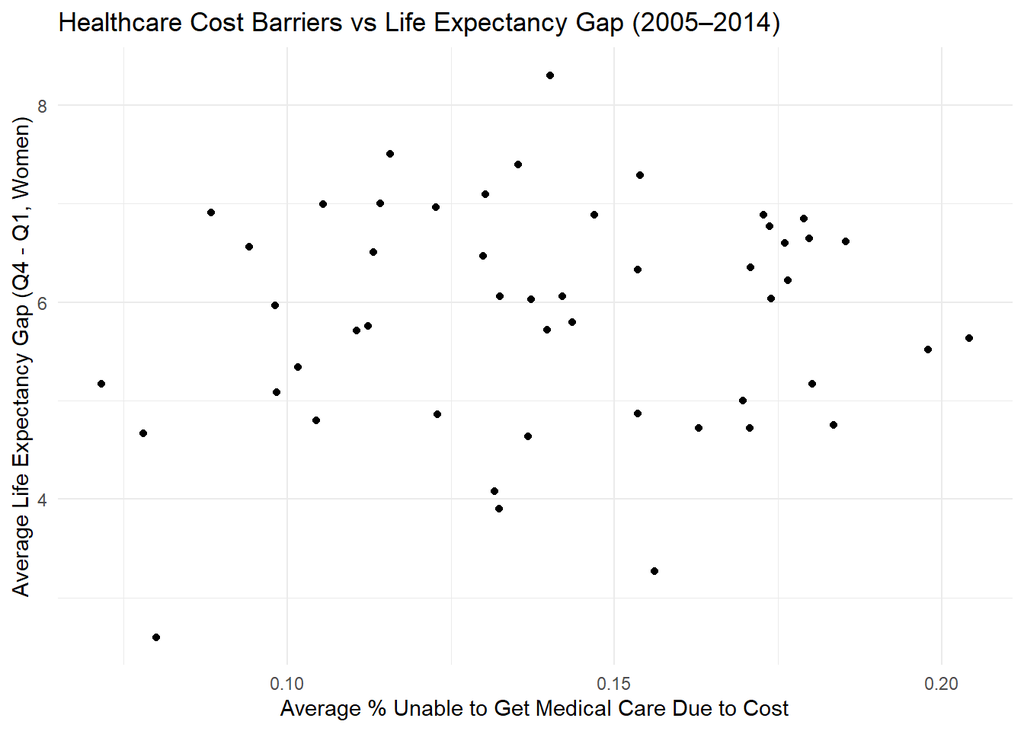

```r
library(ggplot2)

ggplot(summary_df, aes(x = avg_no_care, y = avg_le_gap_F)) +
  geom_point() +
  labs(
    title = "Healthcare Cost Barriers vs Life Expectancy Gap (2005–2014)",
    x = "Average % Unable to Get Medical Care Due to Cost",
    y = "Average Life Expectancy Gap (Q4 - Q1, Women)"
  ) +
  theme_minimal()
```

### New Column

Our summary dataframe looks at the inequality gap summarized by state over all years of data, allowing for quick comparisons. However, when looking at all the data in a more longitudinal manner, it can be helpful to look at year to year changes in inequality between various income quartiles. Therefore, we will add a new column to the data that does exactly this, by first looking at changes in inequality of life expectancy by income quartile, by year.

A negative number will correlate to a decrease in inequality of life expectancy according to income, and a positive number will correlate to an increase.

```r
new_column_joined_df <- joined_df |>
  mutate(
    gap = le_agg_q4_F - le_agg_q1_F,
    gap_change = gap - lag(gap),
    )

glimpse(new_column_joined_df)
```

```
Rows: 450
Columns: 50
$ st                 <int> 1, 1, 1, 1, 1, 1, 1, 1, 1, 2, 2, 2, 2, 2, 2, 2, 2, …
$ stateabbrv         <chr> "AL", "AL", "AL", "AL", "AL", "AL", "AL", "AL", "AL…
$ statename          <chr> "Alabama", "Alabama", "Alabama", "Alabama", "Alabam…
$ year               <int> 2006, 2007, 2008, 2009, 2010, 2011, 2012, 2013, 201…
$ le_agg_q1_F        <dbl> 83.28588, 83.27286, 82.83587, 81.35422, 83.31233, 8…
$ le_raceadj_q1_F    <dbl> 84.08262, 84.08828, 83.73382, 82.34500, 84.25678, 8…
$ le_agg_q2_F        <dbl> 85.27169, 85.84858, 85.33946, 84.87272, 85.19936, 8…
$ le_raceadj_q2_F    <dbl> 85.74873, 86.32239, 85.86448, 85.43463, 85.76780, 8…
$ le_agg_q3_F        <dbl> 85.88442, 87.09906, 85.89401, 87.53565, 87.27370, 8…
$ le_raceadj_q3_F    <dbl> 86.24054, 87.41866, 86.27748, 87.85999, 87.62148, 8…
$ le_agg_q4_F        <dbl> 86.51218, 85.72547, 88.87307, 87.77537, 88.36810, 8…
$ le_raceadj_q4_F    <dbl> 86.80057, 86.04807, 89.07434, 88.03273, 88.60237, 8…
$ le_agg_q1_M        <dbl> 74.94566, 74.35318, 74.64288, 73.70946, 74.05884, 7…
```

[output cut: 37 more lines]

# Group Information

### Group

Our main topic of interest is how healthcare is unevenly accessible within the United States, with factors such as location, income, and medical predispositions ultimately affecting medical care. Our lab section time is 9:30-10:20 on Thursdays (Section BH), and our TA is Kat Ong.

### Lara

Lara Heber (Department of Biology, University of Washington, lheber@uw.edu) is interested in how uncontrollable factors such as location, household income, and preexisting medical conditions result in long term adverse effects out of individual control.

Her interest in data stems from a desire to work with large datasets, particularly those relating to DNA sequencing and human disease.

### Kyana

Kyana Lecksiwilai (The Information School, University of Washington; kylecks@uw.edu) is interested in understanding how cost related barriers to medical care across U.S. states relate to differences in life expectancy, especially when comparing lower and higher income groups over time.

She is interested in informatics and data driven problem solving, and is especially drawn to how real world health data can be used to identify inequities and improve systems of care and access.

### Ana

Ana Moreno (The Information School, University of Washington; mariamor@uw.edu) is interested in exploring how economic inequality shapes differences in life expectancy and access to care.

She is interested in informatics, particularly in how data-driven storytelling and human-centered design can make complex public health issues more accessible and actionable.

### Coding Notes

We primarily used course material to understand the project. For help in loading datasets, Lara used ChatGPT for help in understanding how to format excel files into R, and to organise columns. To do so, she explained the format she had, and asked how to turn it into a more workable dataset, ultimately editing the original excel files. Additionally, in creating a new column, we used the dplyr website (https://dplyr.tidyverse.org/reference/lead-lag.html) to understand how to use the lag function in order to compare values year to year.